# Hito 1 - Grupo 10 - Sección 3

# Análisis de Factores Socioeconómicos y Académicos en el Acceso a la Educación Superior Chilena

Integrantes:

Benjamin Jilberto A. Fabian Pacheco V. Matias Sanhueza S. Pablo Suarez T. Vicente Garrido H.

# 1. Introducción

El presente informe analiza el acceso a la educación superior a partir de datos oficiales provistos por el Ministerio de Educación (Mineduc). Para ello, se emplea un conjunto de datos que cruza los antecedentes de los estudiantes matriculados en 2025 con los resultados de quienes rindieron la Prueba de Acceso a la Educación Superior (PAES) durante ese mismo periodo. La información se estructura en torno a dos dimensiones fundamentales: el rendimiento académico de los postulantes y su contexto socioeconómico y geográfico, evaluado a través de variables como el decil de pertenencia y el ingreso per cápita. Al tratarse de una fuente gubernamental con un alto volumen de registros, los datos ofrecen la solidez estadística necesaria para desarrollar estudios detallados y modelos predictivos confiables.

Analizar esta información es fundamental para comprender las dinámicas del sistema educativo actual. A través de las metodologías adecuadas, este estudio busca visibilizar de manera concreta las brechas de desigualdad que existen al momento de ingresar a la educación superior. Asimismo, permitirá identificar los factores que determinan la trayectoria de los estudiantes, sentando las bases para predecir su futuro académico en función de su realidad socioeconómica.

# 2. Exploración de datos

Para la construcción del conjunto de datos de este hito, se integraron tres fuentes de información distintas, las cuales fueron consolidadas mediante JOINS, utilizando el atributo común *nrun*, que actúa como identificador único para cada estudiante.

Para comprender la estructura general de la base de datos resultante, se analizó su composición general (mediante el método .info()):

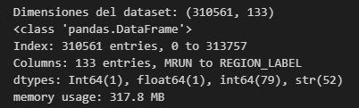

A partir de esta salida, es posible observar que, tras la integración de los datos, el conjunto final quedó compuesto por 310561 registros válidos y 133 variables. Esta exploración inicial permite confirmar los tipos de datos asociados a cada atributo (enteros, flotantes y objetos), así como cuantificar la presencia de valores nulos o faltantes que requieran ser tratados durante la etapa de preprocesamiento.

Posteriormente, se generó un resumen estadístico de las variables numéricas (aplicando el método .describe()) para evaluar su distribución y comportamiento:

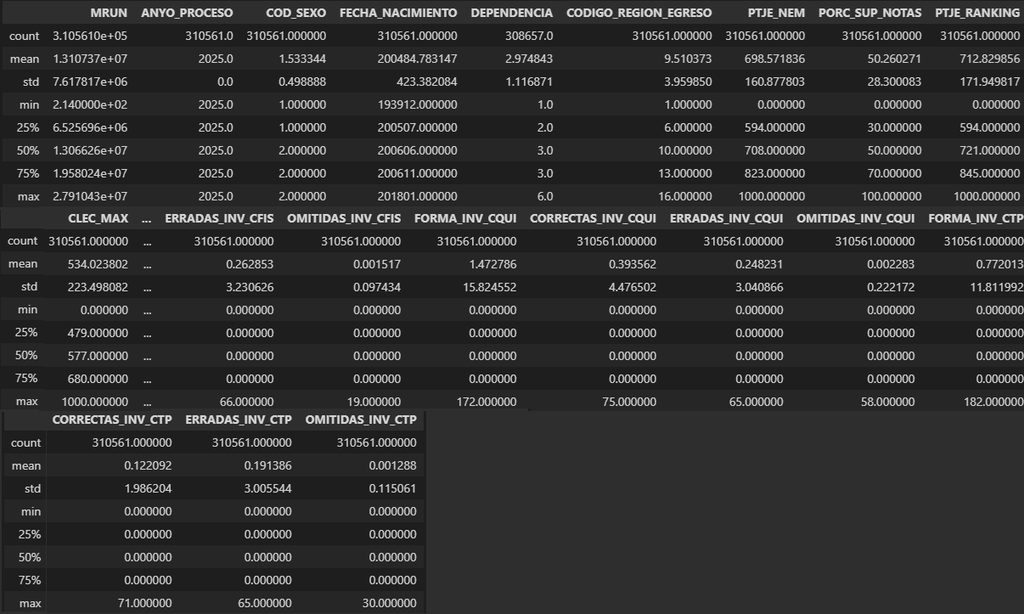

Este análisis descriptivo es fundamental para conocer las medidas de tendencia central y de dispersión del conjunto de datos. A través de métricas como la media, la desviación estándar, los valores mínimos/máximos y los cuartiles, se puede observar a grandes rasgos la distribución de características clave, como los puntajes PAES, el NEM y los indicadores de ingresos. Además, esta tabla facilita la detección temprana de posibles valores atípicos (outliers) o inconsistencias numéricas antes de aplicar los modelos de agrupamiento.

Se realizaron diferentes analisis de los cuales se obtuvo lo siguiente:

## Distribución puntajes leng/mate/nem (general)

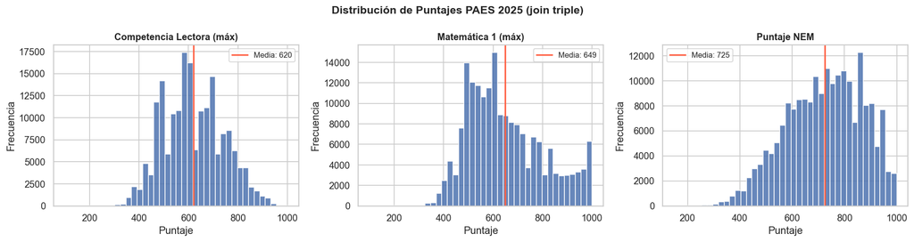

## Distribucion % de deciles región

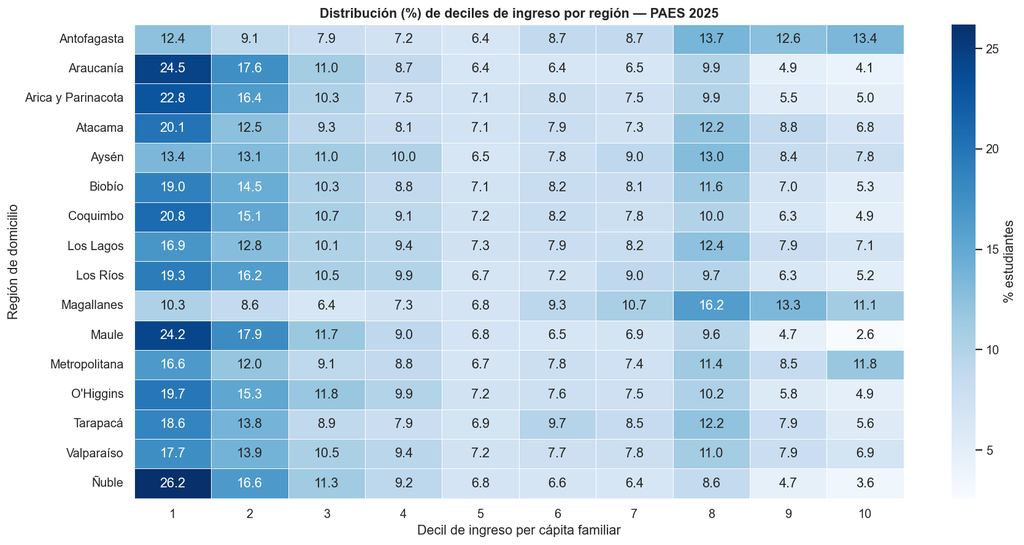

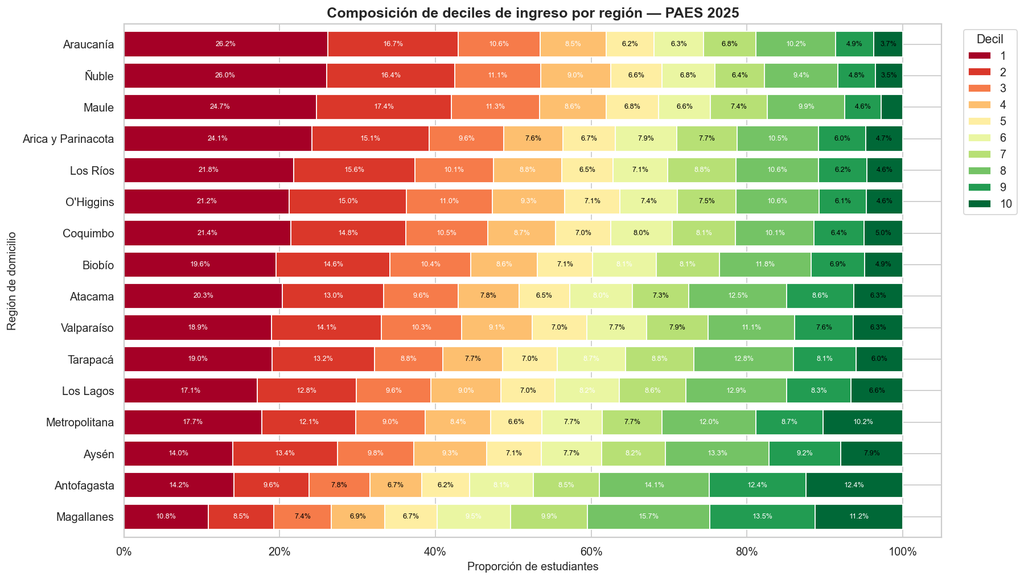

## Preferencia de institución diferenciando entre tipo de institución

- Centros de Formación Técnica
- Institutos Profesionales
- Universidades CRUCH
- Universidades Privadas

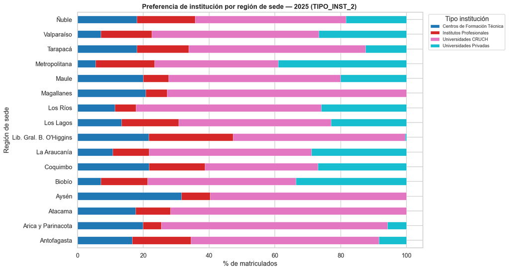

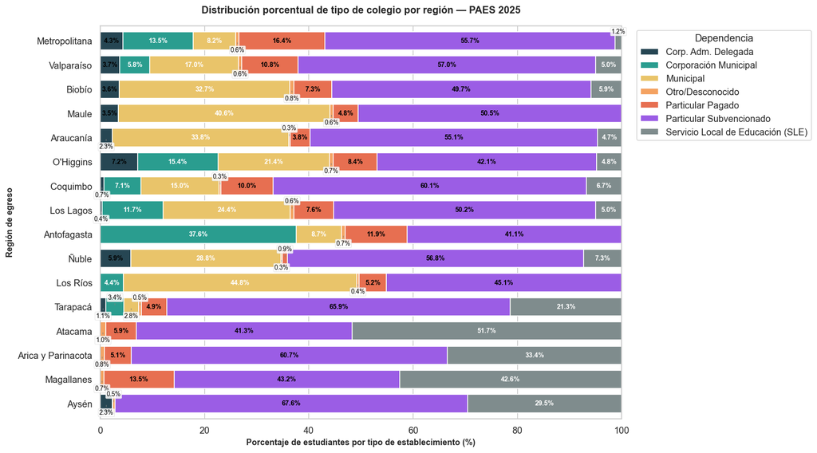

## Distribución porcentual por tipo de colegio

1: 'Corporación Municipal', 2: 'Municipal', 3: 'Particular Subvencionado', 4: 'Particular Pagado', 5: 'Corp. Adm. Delegada', 6: 'Servicio Local de Educación (SLE)'

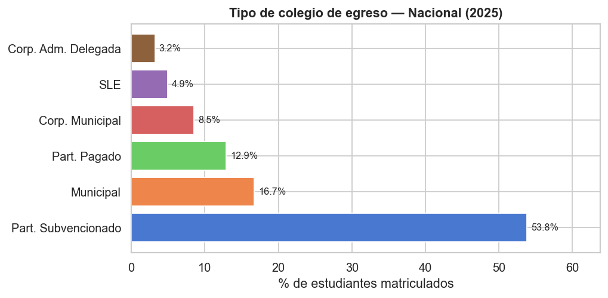

# 3. Preguntas de hipotesis

A partir de la exploración de datos y los objetivos del proyecto, se plantean las siguientes preguntas de investigación y sus respectivas hipótesis, abarcando diferentes enfoques de modelamiento predictivo y descriptivo:

P1 — Clustering (No supervisado): ¿Existen perfiles diferenciados de estudiantes inscritos en la PAES 2025 según sus características socioeconómicas, académicas y geográficas (decil de ingreso, dependencia del colegio, región, puntajes)?

P2 — Regresión (Supervisado): ¿Qué variables socioeconómicas y de escolaridad predicen mejor el puntaje PAES de un estudiante (decil de ingreso, dependencia del colegio, región, rama educacional, NEM)?

P3 — Clasificación multiclase (Supervisado): ¿Es posible predecir el tipo de institución de educación superior en que se matricula un estudiante (Universidad CRUCH, Universidad Privada, CFT/IP) a partir de su puntaje PAES, NEM, dependencia del colegio y decil de ingreso familiar?

P4 — Clasificación binaria (Supervisado): ¿Es posible predecir si un estudiante se matricula en una institución fuera de su región de domicilio, en función de su puntaje PAES, decil de ingreso y disponibilidad de oferta académica local?

# 4. Propuesta Metodológica Experimental

Para responder las preguntas planteadas en este proyecto, se utilizarán distintas técnicas de minería de datos tanto supervisadas como no supervisadas, trabajando sobre el dataset integrado entre matrícula, puntajes PAES y antecedentes socioeconómicos.

Como etapa inicial, se realizó un preprocesamiento de los datos, incluyendo limpieza de registros, eliminación de duplicados, normalización de nombres de columnas y construcción de variables derivadas. Además, se generaron representaciones más interpretables de algunas variables categóricas, como dependencia escolar, región y decil de ingreso.

## P1 — Clustering de perfiles estudiantiles

Para investigar si existen perfiles diferenciados de estudiantes según variables académicas y socioeconómicas, se utilizarán técnicas de clustering sobre un subconjunto del dataset compuesto por variables como puntajes PAES, puntaje NEM, dependencia escolar, región de origen y decil de ingreso familiar.

Debido a la cantidad de variables presentes, se aplicará PCA para reducir dimensionalidad y facilitar la visualización de los datos en 2 dimensiones.

Posteriormente, se probarán distintos métodos de clustering jerárquico (complete, single, average y ward), además de DBSCAN. Los resultados serán visualizados mediante dendrogramas y gráficos en 2D utilizando los componentes principales generados por PCA.

La selección de parámetros, como el número de clusters o el valor eps en DBSCAN, se realizará utilizando análisis visual y métodos como la curva de rodilla basada en KNN.

## P2 — Predicción del puntaje PAES

Para analizar qué factores influyen en el rendimiento académico, se abordará el problema mediante modelos de regresión.

Se utilizarán variables como:

- decil de ingreso,
- dependencia escolar,
- región,
- NEM,
- ranking.

Inicialmente se probarán modelos de regresión lineal y modelos basados en árboles, comparando su desempeño mediante métricas como R².

También se evaluará si existen relaciones no lineales entre variables utilizando transformaciones polinomiales.

## P3 — Predicción del tipo de institución

Para determinar si es posible predecir el tipo de institución de educación superior al que accede un estudiante, se abordará el problema como una tarea de clasificación multiclase.

La variable objetivo corresponderá al tipo de institución:

- Universidad CRUCH.
- Universidad Privada.
- Instituto Profesional.
- Centro de Formación Técnica.

Las variables predictoras incluirán:

- Puntajes PAES.
- Puntaje NEM.
- Dependencia del colegio.
- Decil de ingreso.
- Región de origen.

Se utilizarán distintos modelos de clasificación, tales como:

- Árboles de decisión.
- Random Forest.
- Regresión logística.

El desempeño de los modelos será evaluado utilizando métricas como accuracy, precision, recall y F1-score, además de matrices de confusión para analizar los errores de clasificación.

## P4 — Migración regional estudiantil

Para analizar si es posible predecir cuándo un estudiante se matriculará fuera de su región de origen, se construyó una variable binaria denominada “migra”.

Esta variable toma el valor:

- 1 si la región de matrícula es distinta de la región de domicilio.
- 0 en caso contrario.

Se utilizarán modelos de clasificación binaria utilizando variables como:

- Puntajes PAES.
- Decil socioeconómico.
- Tipo de establecimiento escolar.
- Región de origen.
- Oferta académica regional.

Además, se realizará un análisis territorial mediante mapas de calor y tasas de migración por región, con el objetivo de identificar patrones de centralización educativa y posibles desigualdades territoriales.

## Evaluación general

Los modelos serán comparados utilizando conjuntos de entrenamiento y prueba, evaluando tanto desempeños predictivos como capacidad de generalización.

En general la metodología busca poder identificar patrones relevantes relacionados con desigualdad educativa, movilidad territorial y acceso a la educación superior en Chile.

# 5. Experimento Preliminar — P1 Clustering

Siguiendo la propuesta metodológica de la sección anterior, se implementa el experimento completo para **P1**: identificar perfiles diferenciados de estudiantes PAES 2025 según sus características socioeconómicas, académicas y geográficas.

Se aplica KMeans con método del codo para seleccionar k, se evalúa con Silhouette score y se visualiza con PCA 2D.

**Dataset:** Join entre archivo de puntajes (A) y socioeconómico (B) por MRUN. Tras filtrar estudiantes que no rindieron la PAES (puntaje = 0) y quienes no reportaron decil de ingreso, se trabajó con **194.596 estudiantes** válidos.

**Features usadas:** `clec_max`, `mate1_max`, `ptje_nem`, `ptje_ranking`, `dependencia`, `ingreso_percapita_grupo_fa`, `codigo_region_domicilio`. Escaladas con `StandardScaler`.

## Selección del número de clusters

Se evaluó KMeans para k = 2 a 8 usando el método del codo (inercia) y el coeficiente de Silhouette (con muestra de 10.000 estudiantes para eficiencia).

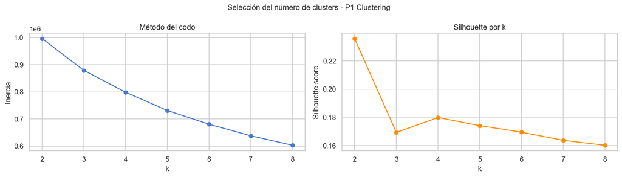

## Visualización PCA 2D

Reducción a 2 componentes principales (PC1 explica el 40.6% de la varianza, PC2 el 16.6%). Se grafican 20.000 estudiantes al azar para visualizar la estructura de los clusters.

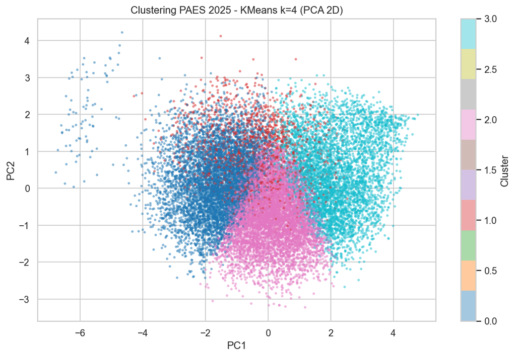

## Puntajes promedio por cluster

Puntaje promedio de Competencia Lectora, Matemática 1 y NEM para cada cluster.

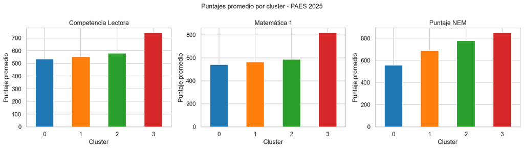

## Perfil socioeconómico por cluster

Decil de ingreso per cápita familiar promedio y tipo de colegio (dependencia) por cluster.

Referencia dependencia: 1=Corp. Municipal, 2=Municipal, 3=Part. Subvencionado, 4=Part. Pagado, 5=Corp. Adm. Delegada, 6=SLE.

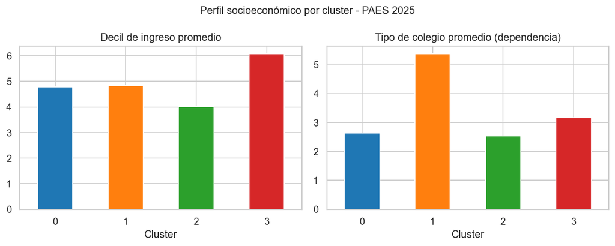

## Interpretación de resultados

Con k=4 y Silhouette de 0.18, se identificaron 4 perfiles diferenciados:

| Cluster | N | CLEC | MATE1 | NEM | Decil | Dependencia |
| --- | --- | --- | --- | --- | --- | --- |
| 0 | 62.131 | 533 | 541 | 555 | 4.8 | Municipal |
| 1 | 16.470 | 553 | 562 | 686 | 4.8 | Corp. Adm. Delegada/SLE |
| 2 | 67.055 | 580 | 586 | 776 | 4.0 | Municipal/Part. Subv. |
| 3 | 48.940 | 742 | 818 | 849 | 6.1 | Part. Subv./Pagado |

- **Cluster 0 (rendimiento bajo, contexto vulnerable):** Puntajes PAES medianos-bajos (533/541) y NEM bajo (555), con decil 4.8 y colegios municipales (dependencia promedio 2.6).
- **Cluster 1 (técnico-profesionales):** Puntajes PAES similares al cluster 0 pero NEM considerablemente más alto (686). La dependencia promedio de 5.4 corresponde a Corp. Adm. Delegada y SLE, típicos de educación técnico-profesional. El NEM alto con PAES moderado sugiere que estos colegios califican bien internamente pero sus estudiantes rinden menos en la prueba estandarizada.
- **Cluster 2 (buen rendimiento, bajo ingreso):** Puntajes intermedios (580/586) con NEM alto (776) y decil bajo (4.0) en colegios municipales y particulares subvencionados. Perfil de estudiante aplicado en contexto de vulnerabilidad.
- **Cluster 3 (alto rendimiento, mayor ingreso):** Los mejores puntajes (742/818) y NEM de 849, con decil 6.1 y colegios particulares subvencionados a pagados. Reflejan la ventaja del contexto socioeconómico favorable.

**Ajustes para el Hito 2:**

- Comparar k=3 vs k=4 y justificar formalmente la elección.
- Analizar si el cluster 1 corresponde efectivamente a educación técnico-profesional usando `RAMA_EDUCACIONAL`.
- Aplicar clustering jerárquico (Ward) y DBSCAN para comparar con KMeans, según lo propuesto en la sección 4.

# Anexos

En este apartado de Anexo, se entregan links a los codigos que permitieron generar los graficos vistos tanto en la parta 2 y 5

[Codigos_1](https://drive.google.com/file/d/1TWO9vO2NlFLS4nL9EKs5tak6sZDdHGjk/view?usp=sharing)